# lme4qtl: an efficient and flexible QTL mapper

17 May, 2016  
bit.ly/1OvML1a

## About lme4qtl

[figure not shown]

Source: github.com/dmbates

lme4qtl \(=\) an extension of the lme4 R package

lme4qtl \(=\) linear mixed effects models for 4 quantitative trait loci mapping

## lme4qtl applied to GAIT2

## lme4qtl applied to GAIT2

1. Risk model of Thrombosis
2. Use case: PFA as a new risk factor
3. Model of APTT

Intereseted to know more about lme4qtl?

Please see the slides bit.ly/1UiTZvQ introducing the lme4qtl R package.

## Risk model of Thrombosis

- No covariates: meaning of prevalence
- Basic model: age & gender
  - How to code age?
  - Is gender important?
- Adding a genetic factor: ABO
  - How to encode ABO?
- Adding more genetic factors
  - In TIC we trust

## Use case: PFA as a new risk factor

- PFAadp & PFAedp have been established as risk factors in RETROVE
  - ABO is not available in RETROVE
- Replication study in GAIT2
  - ABO is available in GAIT2
  - Measures of PFAadp & PFAedp are comparable across two cohorts
- lme4qtl R packages handles the pedigrees
  - SOLAR hasn't heard about logistic legression
  - SOLAR has a special way to introduce the disease prevalence

## Model of APTT

- Sex-specificity
- Ageing
- Combined linkage and association

## Risk model of Thrombosis

## Thrombosis disease

Thrombosis is a common complex disease associated with substantial morbidity and mortality.

The major determinants of thrombosis include both environmental and genetic factors.

- Enironmental: age & gender
- Genetic: ABO blood group system ([wikipedia](https://en.wikipedia.org/wiki/ABO_blood_group_system))
  - Group O is protector

The contribution of genetic risk factors is estimated around 60% (Souto et al. 2000).

## No covariates: meaning of prevalence

```r
m <- relmatGlmer(Throm ~ (1|ID), phen2, relmat = list(ID = dkin2),
  family = binomial)
```

- Model intercept: \(\beta_0 =\) -2.32
- Formula for the prevalence (logistic regression): \(\frac{1}{1 + e^{-\beta_0}}\)

[output not shown]

## Modeling prevalence?

```r
K <- 0.02
dat <- mutate(phen2, offset = log(K/(1 - K)))
m <- relmatGlmer(Throm ~ -1 + AGEsc + (1|ID), dat,
  offset = offset, relmat = list(ID = dkin2), family = binomial)
```

GAIT2 (118 *vs.* 817)

GAIT1 (53 *vs.* 340)

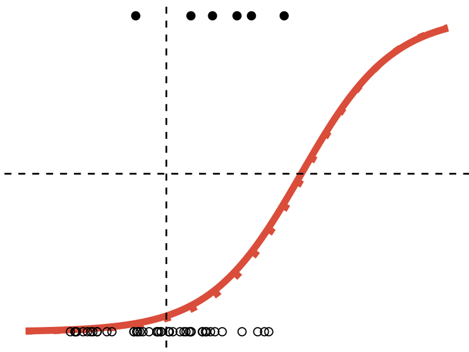

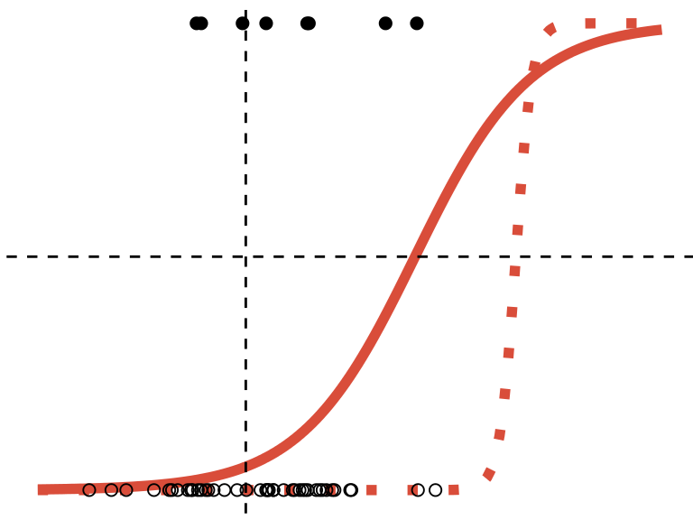

## Effects of age & gender

```r
K <- 0.02
dat <- mutate(phen2, offset = log(K/(1 - K)))
m <- relmatGlmer(Throm ~ -1 + AGEsc + I(AGEsc^2) + SEXfnum + (1|ID), dat,
  offset = offset, relmat = list(ID = dkin2), family = binomial)
stats <- drop1(m, test = "Chisq")
```

|  | P-value |
| --- | --- |
| AGEsc | 2.96e-18 |
| I(AGEsc^2) | 0.704 |
| SEXfnum | 0.346 |

## AGE^2 is not significant?

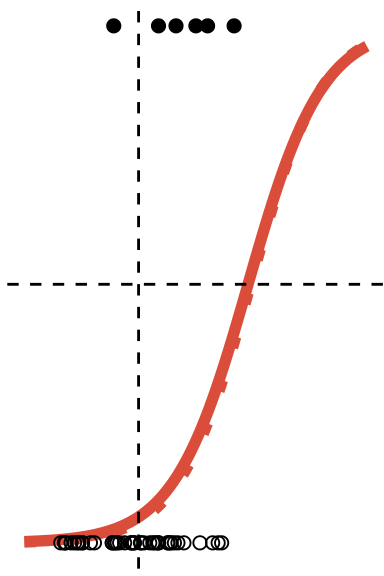

Does that mean there is no non-linear trend?

- Could be true for the linear regression
  - model: `APTT ~ AGE + AGE^2`
- Not the case for the logistic regression
  - model: `Throm ~ AGE + AGE^2`

See also (V ázquez-Santiago et al. 2016)

## Non-linear age effect

|  | Factor level of AGE | Range of AGE | Number of ind. |
| --- | --- | --- | --- |
| < 55 | 0 | [ 2.6 - 54.8 ] | 715 |
| 55 - 64 | 1 | [ 55.2 - 64 ] | 79 |
| 65 - 74 | 2 | [ 64.1 - 73.8 ] | 81 |
| 75 - 84 | 3 | [ 74.1 - 83.9 ] | 43 |
| > 85 | 4 | [ 84.2 - 101.1 ] | 17 |

## Non-linear age effect

```r
K <- 0.05
dat <- mutate(phen2, offset = log(K/(1 - K)))
m <- relmatGlmer(Throm ~ -1 + AGEfnum1 + AGEfnum2 + AGEfnum3 + AGEfnum4 + SEXfnum + (1|ID), dat,
  offset = offset, relmat = list(ID = dkin2), family = binomial)
stats <- drop1(m, test = "Chisq")
```

|  | Odds | CI 5% | CI 95% | P-value |
| --- | --- | --- | --- | --- |
| 55 - 64 | 4.03 | 2.38 | 6.83 | 9.32e-05 |
| 65 - 74 | 7.14 | 4.41 | 11.6 | 1.38e-09 |
| 75 - 84 | 10.1 | 5.47 | 18.7 | 2.32e-08 |
| > 85 | 13.8 | 5.31 | 35.9 | 2.42e-05 |

## ORs + 90% CI *vs.* ORs in TiC

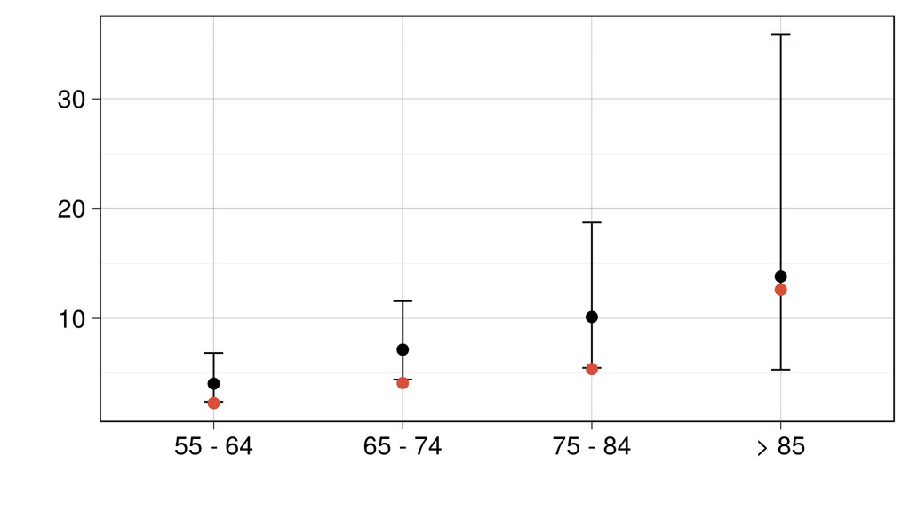

Is that publishable? Ask Sr. Tripodi about his article in Blood.

## Encoding ABO: allele O

| ABO | Code_0 | Code_1 | Code_2 |
| --- | --- | --- | --- |
| O1/O2 | 0 | 0 | 30 |
| O1/O1 | 0 | 0 | 266 |
| A2/O2 | 0 | 3 | 0 |
| B/O2 | 0 | 4 | 0 |
| A1/O2 | 0 | 18 | 0 |
| O1/A2 | 0 | 36 | 0 |
| O1/B | 0 | 83 | 0 |
| A1/O1 | 0 | 306 | 0 |
| A2/A2 | 1 | 0 | 0 |
| B/B | 4 | 0 | 0 |
| B/A2 | 15 | 0 | 0 |
| A1/A2 | 19 | 0 | 0 |
| A1/B | 38 | 0 | 0 |
| A1/A1 | 90 | 0 | 0 |
| NA | NA | NA | NA |

## Encoding ABO: allele A1

| ABO | Code_0 | Code_1 | Code_2 |
| --- | --- | --- | --- |
| A1/A1 | 0 | 0 | 90 |
| A1/O2 | 0 | 18 | 0 |
| A1/A2 | 0 | 19 | 0 |
| A1/B | 0 | 38 | 0 |
| A1/O1 | 0 | 306 | 0 |
| A2/A2 | 1 | 0 | 0 |
| A2/O2 | 3 | 0 | 0 |
| B/B | 4 | 0 | 0 |
| B/O2 | 4 | 0 | 0 |
| B/A2 | 15 | 0 | 0 |
| O1/O2 | 30 | 0 | 0 |
| O1/A2 | 36 | 0 | 0 |
| O1/B | 83 | 0 | 0 |
| O1/O1 | 266 | 0 | 0 |
| NA | NA | NA | NA |

## Adding ABO genetic factor

```r
K <- 0.05
dat <- mutate(subset(phen2, !is.na(ABOf3num)), offset = log(K/(1 - K)))

m <- relmatGlmer(Throm ~ -1 + AGEsc + AGEsc2 + SEXfnum + ABOf3num + (1|ID), dat,
  offset = offset, relmat = list(ID = dkin2), family = binomial)
```

|  | Estimate | Std. Error | P-value |
| --- | --- | --- | --- |
| AGEsc | 1.39 | 0.222 | 6.21e-18 |
| AGEsc2 | 0.0271 | 0.139 | 0.847 |
| SEXfnum | 0.311 | 0.266 | 0.264 |
| ABOf3num | -0.575 | 0.243 | 0.00439 |

## Adding more genetic factors

Two perpectives

1. GWAS
2. Risk models (logistic regression)

## The most modern GWAS

GWAS of self-reported events in 6,135 individuals and 252,827 controls identifies 8 thrombosis-related loci (Hinds et al. 2016):

- F5, FGA-FGG, F11, F2, PROCR, and ABO
- Recently discovered locus near SLC44A2

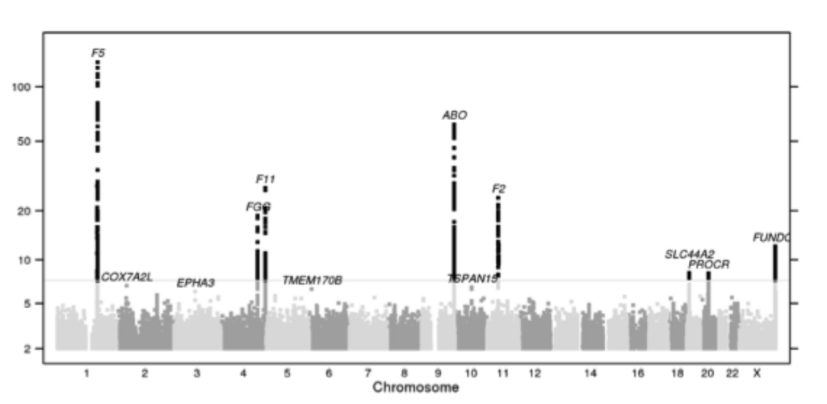

## Known SNPs & Relative Risks (10/26)

| Marker | RR | Gene | MAF |
| --- | --- | --- | --- |
| rs121909548 | 10 | SERPINC1 | 2e-04 |
| rs6025 | 5 | F5 | 0.006 |
| rs1801020 | 5 | F12 | 0.472 |
| rs1799963 | 4 | F2 | 0.0036 |
| rs8176719 | 4 | ABO | NA |
| rs8176750 | 4 | ABO | NA |
| rs2232698 | 3.3 | SERPINA10 | 0.0054 |
| rs2066865 | 1.47 | FGG | 0.303 |
| rs2036914 | 1.35 | F11 | 0.394 |
| rs2289252 | 1.35 | F11 | 0.32 |

## Protocol

Data preparation

- Remove SNPs not presented in GAIT2
- Remove SNPs with MAF < 5%

Selection of SNPs

1. The null model: age & gender
2. Add one SNP at a time
3. Select the most significant one (if any)
4. Go to step 2

## SNPs out of the analysis

|  | Marker | RR | Gene | MAF | maf.imputed | GAIT2 |
| --- | --- | --- | --- | --- | --- | --- |
| 1 | rs121909548 | 10 | SERPINC1 | 2e-04 | 0.00857 | TRUE |
| 2 | rs6025 | 5 | F5 | 0.006 | 0.00808 | TRUE |
| 4 | rs1799963 | 4 | F2 | 0.0036 | 0.0282 | TRUE |
| 6 | rs8176750 | 4 | ABO | NA | 0.0418 | TRUE |
| 7 | rs2232698 | 3.3 | SERPINA10 | 0.0054 | 0.00696 | TRUE |
| 25 | rs118203906 | NA | F5 | 2e-04 | NA | FALSE |
| 26 | rs118203905 | NA | F5 | 0.002 | NA | FALSE |

## Final multi-marker model

```r
m <- relmatGlmer(Throm ~ AGEsc + AGEsc2 + SEXfnum + rs8176719 + rs2036914 + rs2288904 + (1|ID), dat,
  relmat = list(ID = dkin2), family = binomial)
```

| Marker | Odds | CI 5% | CI 95% | P-value | Gene | RR |
| --- | --- | --- | --- | --- | --- | --- |
| rs8176719 | 1.67 | 1.2 | 2.31 | 0.0102 | ABO | 4 |
| rs2036914 | 2.06 | 1.45 | 2.91 | 0.000691 | F11 | 1.35 |
| rs2288904 | 1.54 | 1.08 | 2.2 | 0.0463 | SLC44A2 | 1.2 |

## GAIT2 is comparable to 23andme?

- In both cohors: FGA-FGG, F11, PROCR, SLC44A2, and ABO (O-related SNP)
- Excluded in GAIT2: F5, F2, and ABO (A1-related SNP MAF 0.04)
- Other risk markers:
  - F12 SNP affects on FXIIc or Throm?
  - SERPINC1/SERPINA10/Cambridge are rare

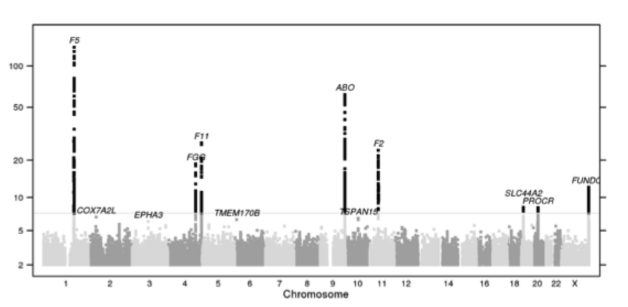

## ABO SNPs

From the literature review of risky SNPs:

| Allele | SNP |
| --- | --- |
| O | rs8176719 |
| A1 | rs8176750 |

(Loon et al. 2015) :

> Blood group antigen phenotypes (O and non-O) were reconstructed using genotype data of rs687289:C4T, which is a marker for the O allele. [26]

## ABO in RETROVE?

Use rs687289:C4T to define blood antigen phenotypes (O and non-O)?

## Use case

### PFA as a new risk factor: discovered in RETROVE

## Results in RETROVE

Shortened times of both PFAadp & PFAepin (10% quantile) have been found to be risk factors

- Base model used for comparison included: age & gender
- ABO factor was omitted (data not measured in RETROVE)

## GWAS of PFA phenotypes in GAIT2

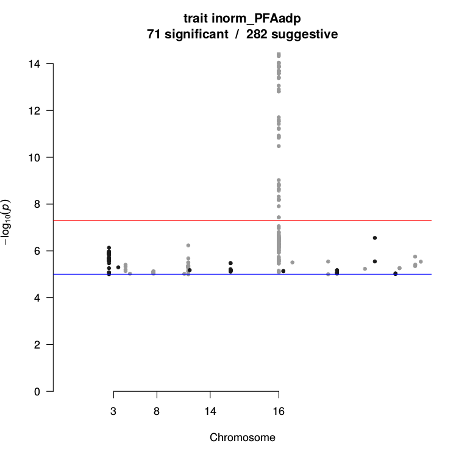

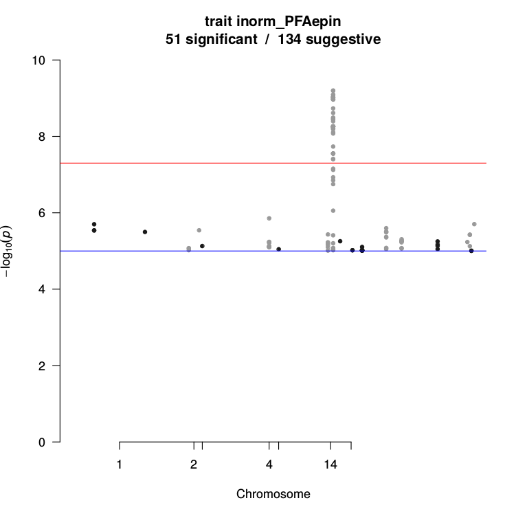

## Protocol in GAIT2

- Define quantile 10% based on controls in GAIT2
- Use rs8176719 (934) instead of ABO genotype (913)
- Use lme4qtl to take into account related individuals

## Results in GAIT2

| Model | Odds | Pvalue |
| --- | --- | --- |
| Throm ~ AGE + AGE^2 + SEX + PFAadp_q10 | 1.63 [0.71; 3.73] | 0.268 |
| Throm ~ AGE + AGE^2 + SEX + rs8176719 + PFAadp_q10 | 1.29 [0.49; 3.44] | 0.614 |

| Model | Odds | Pvalue |
| --- | --- | --- |
| Throm ~ AGE + AGE^2 + SEX + PFAepin_q10 | 0.99 [0.45; 2.17] | 0.978 |
| Throm ~ AGE + AGE^2 + SEX + rs8176719 + PFAepin_q10 | 0.89 [0.36; 2.18] | 0.79 |

## Summary on PFA in GAIT2

We can not conclude the interplay effect between PFA & AB0.

- PFA shows no significant effect in any model.

Can be GAIT2 used to replicate results in RETROVE?

- Most GAIT2 affected have multiple thrombotic events
- Relatedness can be corrected by lme4qtl
  - GAIT2 is biased due to family history (risk factor)
  - MARTHA is biased due to FV/PT factors

## Conclusions

## What next?

- Re-run GWAS on diseases
  - Take into account the prevalence
  - Take into account known markers (Zaitlen et al. 2012)
- Run ageing & sex-specificity models
  - Use GAW sample (GAIT1 showed no results)
- Run risk model of Thrombosis with 10M markers
  - regularized mixed models (todo lme4qtl)
- Run multi-level model for CVI
  - ordered logistic regerssion (todo lme4qtl)

## Thank you

## References

Hinds, David A, Alfonso Buil, Daniel Ziemek, Angel Martinez-Perez, Rainer Malik, Lasse Folkersen, Marine Germain, et al. 2016. “Genome-wide association analysis of self-reported events in 6 , 135 individuals and 252 , 827 controls identifies 8 loci associated with thrombosis.” *Human Molecular Genetics*, 1–31.

Loon, Janine van, Abbas Dehghan, Tang Weihong, Stella Trompet, Wendy L McArdle, Folkert FW Asselbergs, Ming-Huei Chen, et al. 2015. “Genome-Wide Association Studies Identify Genetic Loci for Low von Willebrand Factor Levels.” *European Journal of Human Genetics*. Nature Publishing Group.

Souto, Juan Carlos, Laura Almasy, Montserrat Borrell, Francisco Blanco-Vaca, Jos é Mateo, Jos é Manuel Soria, Inma Coll, et al. 2000. “Genetic Susceptibility to Thrombosis and Its Relationship to Physiological Risk Factors: The GAIT Study.” *The American Journal of Human Genetics* 67 (6). Elsevier: 1452–59.

V ázquez-Santiago, Miquel, Andrey Ziyatdinov, N úria Pujol-Moix, Helena Brunel, Agn ès Morera, Jos é Manuel Soria, and Juan Carlos Souto. 2016. “Age and Gender Effects on 15 Platelet Phenotypes in a Spanish Population.” *Computers in Biology and Medicine* 69. Pergamon: 226–33.

Zaitlen, Noah, Bogdan Paşaniuc, Nick Patterson, Samuela Pollack, Benjamin Voight, Leif Groop, David Altshuler, et al. 2012. “Analysis of Case–control Association Studies with Known Risk Variants.” *Bioinformatics* 28 (13): 1729–37. doi:10.1093/bioinformatics/bts259.